```python
%%capture
#!python -m spacy download en
#!pip install --no-cache-dir wordcloud
#!pip3 install --no-cache-dir -U folium!pip install --no-cache-dir textblob
#!pip install plotly
from datascience import make_array
from datascience import *
import numpy as np
import matplotlib.pyplot as plt
from ipywidgets import *
%matplotlib inline
import folium
import pandas as pd
from IPython.display import HTML, display, IFrame
import folium
import spacy
from wordcloud import WordCloud
#from textblob import TextBlob
import geojson
from sklearn import datasets, linear_model
from sklearn.model_selection import train_test_split
from matplotlib import pyplot as plt
from collections import Counter
import plotly.plotly as py
import plotly.graph_objs as go
import cv2
```

# How Can We Quantify the Media Bias Chart?

Some Definitions

```python
def count_nonzero(df, keyword_list):
    keyword_list
    for i in np.arange(len(keyword_list)):
        BOOL = df.isin([keyword_list[i]])
        LENGTH = len(df.iloc[0])
        df_new = df.iloc[0:0]
        new_list = []
        for i in np.arange(LENGTH):
            df0 = BOOL.iloc[:,i].value_counts()
        newer = new_list.append(df0)
    data = pd.DataFrame(columns = selections_train, data = [newer], index = [keyword_list])
    data0 = df_new.append(data)
    return newer
```

Counts how many words in a set of keywords are in a dataframe

```python
from numpy import nan
def tokenize_df(df):
    empty = []
    four = []
    for i in range(len(df)):
        first = df.iloc[i][1]
        tokenized = tokenize(df, i)
        two = (tokenized)
        three = empty.append(two)
        aaa = (df.iloc[i][0])
        five = four.append(aaa)
    one = pd.DataFrame(data = empty, index = [four])
    return one
```

Makes a dataframe into a tokenized dataframe

```python
def count_nonzero_df(df, keyword_list):
    BOOL = df.isin(keyword_list)
    LENGTH = len(df.iloc[0])
    df_new = df.iloc[0:0]
    new_list = []
    for i in np.arange(LENGTH):
        df0 = BOOL.iloc[:,i].value_counts()[1]
        new_list.append(df0)
    data = pd.DataFrame(columns = selections_train, data = [new_list], index = ["Keywords"])
    return data
```

Does the same as count_nonzero, but gives a whole dataframe

```python
plt.close("all")
```

```python
colors = ("red","orange","yellow", "green", "blue", "purple", "gray", "black", "brown", "pink")

#consistent colors
```

Loads all the outlets in the chart

```python
media = pd.DataFrame(index = ["PATRIBIOTICS","REALFARMACY.COM","PALMER REPORT","OCCUPY DEMOCRATS","BIPARTISAN REPORT",
                     "DAVID WOLFE","FORWARD PROGRESSIVES","ALTERNET","DAILY KOS","SECOND NEXUS","NEW REPUBLIC",
                     "BUZZFEED NEWS","HUFFINGTON POST","MSNBC","CNN","MOTHER JONES","MIC","VANITY FAIR",
                     "DAILY BEAST","SLATE","VOX","THE ATLANTIC","THE WEEK","THE INTERCEPT","THE NATION",
                     "THE NEW YORKER","JACOBIN","DEMOCRACY NOW","THE GUARDIAN","THE WASHINGTON POST",
                     "THE NEW YORK TIMES","AXIOS","BBC","NPR","POLITICO","NBC NEWS","ABC NEWS","CBS NEWS",
                     "AFP","AP","REUTERS","BLOOMBERG","USA TODAY","PBS","THE CHRISTIAN SCIENCE MONITOR",
                     "THE HILL","THE WALL STREET JOURNAL","TIME","FP","THE ECONOMIST","THE FISCAL TIMES",
                     "NATIONAL REVIEW","THE WEEKLY STANDARD","REASON.COM","WASHINGTON EXAMINER",
                     "THE WASHINGTON TIMES","THE AMERICAN CONSERVATIVE","THE FEDERALIST","OAN","DRUDGE REPORT",
                     "NEW YORK POST","DAILY MAIL","FOX NEWS","DAILY WIRE","THE CONSERVATIVE TRIBUNE",
                     "THE DAILY CALLER","NEWSMAX","REDSTATE","BRIETBART","THE BLAZE","INFOWARS","WORLDTRUTH.TV",
                     "NATURAL NEWS","NATIONAL ENQUIRER"])
media
```

| PATRIBIOTICS |
| --- |
| REALFARMACY.COM |
| PALMER REPORT |
| OCCUPY DEMOCRATS |
| BIPARTISAN REPORT |
| DAVID WOLFE |
| FORWARD PROGRESSIVES |
| ALTERNET |
| DAILY KOS |
| SECOND NEXUS |
| NEW REPUBLIC |
| BUZZFEED NEWS |
| HUFFINGTON POST |
| MSNBC |
| CNN |
| MOTHER JONES |
| MIC |
| VANITY FAIR |
| DAILY BEAST |
| SLATE |
| VOX |
| THE ATLANTIC |
| THE WEEK |
| THE INTERCEPT |
| THE NATION |
| THE NEW YORKER |
| JACOBIN |
| DEMOCRACY NOW |
| THE GUARDIAN |
| THE WASHINGTON POST |
| ... |
| THE CHRISTIAN SCIENCE MONITOR |
| THE HILL |
| THE WALL STREET JOURNAL |
| TIME |
| FP |
| THE ECONOMIST |
| THE FISCAL TIMES |
| NATIONAL REVIEW |
| THE WEEKLY STANDARD |
| REASON.COM |
| WASHINGTON EXAMINER |
| THE WASHINGTON TIMES |
| THE AMERICAN CONSERVATIVE |
| THE FEDERALIST |
| OAN |
| DRUDGE REPORT |
| NEW YORK POST |
| DAILY MAIL |
| FOX NEWS |
| DAILY WIRE |
| THE CONSERVATIVE TRIBUNE |
| THE DAILY CALLER |
| NEWSMAX |
| REDSTATE |
| BRIETBART |
| THE BLAZE |
| INFOWARS |
| WORLDTRUTH.TV |
| NATURAL NEWS |
| NATIONAL ENQUIRER |

74 rows × 0 columns

Removing those without articles on "Transgender" Methodology: went through each site, searched "Transgender", listed all that had no articles. Sometimes had to go to Facebook pages, etc when sites were not cooperating. Took most recent article from each site with Transgender or Trans in the title, copied ONLY the text of the article, not the title, and not the extra text at the end like "please support our website". All data was collected between 12pm and 9pm on 4 April 2018. JACOBIN'S latest article was from several years ago. I omitted those behind a paywall (WSJ)

```python
no_trans = ["PATRIBIOTICS","AFP","AP","OAN","DRUDGE REPORT", "THE WALL STREET JOURNAL"]
without_trans = media.drop(no_trans)
```

train = train.sample(10) train

Train gave us "MIC" "THE NEW YORKER" "FP" "PBS" "MOTHER JONES" "THE ATLANTIC" "FOX NEWS" "NPR" "BUZZFEED NEWS" and "THE DAILY CALLER"

```python
selections_train = ["MIC","THE NEW YORKER","FP","PBS","MOTHER JONES","THE ATLANTIC","FOX NEWS","NPR",
                   "BUZZFEED NEWS","THE DAILY CALLER"]
selected_train = pd.DataFrame(index = range(len(selections_train)), data = (selections_train), columns = ["TRAIN"])
selected_train
```

|  | TRAIN |
| --- | --- |
| 0 | MIC |
| 1 | THE NEW YORKER |
| 2 | FP |
| 3 | PBS |
| 4 | MOTHER JONES |
| 5 | THE ATLANTIC |
| 6 | FOX NEWS |
| 7 | NPR |
| 8 | BUZZFEED NEWS |
| 9 | THE DAILY CALLER |

select_test = without_trans.drop(selections) select_test.sample(10)

select_test gave us "THE AMERICAN CONSERVATIVE","THE GUARDIAN","VOX","WASHINGTON EXAMINER","DEMOCRACY NOW","MSNBC","NEW REPUBLIC","ABC NEWS","BIPARTISAN REPORT","DAILY WIRE"

```python
selections_test =["THE AMERICAN CONSERVATIVE","THE GUARDIAN","VOX","WASHINGTON EXAMINER","DEMOCRACY NOW","MSNBC",
                  "NEW REPUBLIC","ABC NEWS","BIPARTISAN REPORT","DAILY WIRE"]
selected_test = pd.DataFrame(index = range(len(selections_test)), data = selections_test, columns = ["TEST"])
#makes a dataframe of our trial outlets
selected_test
```

|  | TEST |
| --- | --- |
| 0 | THE AMERICAN CONSERVATIVE |
| 1 | THE GUARDIAN |
| 2 | VOX |
| 3 | WASHINGTON EXAMINER |
| 4 | DEMOCRACY NOW |
| 5 | MSNBC |
| 6 | NEW REPUBLIC |
| 7 | ABC NEWS |
| 8 | BIPARTISAN REPORT |
| 9 | DAILY WIRE |

Identify where on the graph they are.

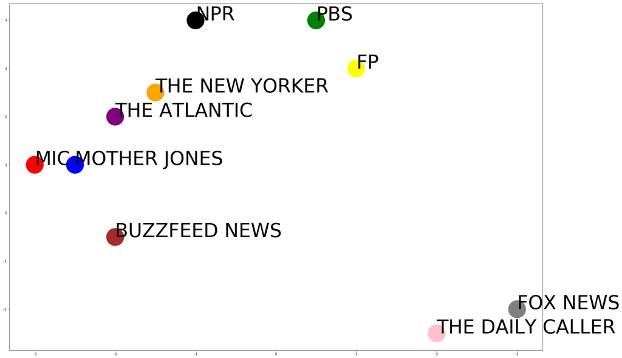

```python
media_bias_train = pd.DataFrame({"x":[-3,-1.5,1,.5,-2.5,-2,3,-1,-2,2],
                                 "y":[1,2.5,3,4,1,2,-2,4,-.5,-2.5]},
                                index = selections_train)

x0 = [-3,-1.5,1,.5,-2.5,-2,3,-1,-2,2]
y0 = [1,2.5,3,4,1,2,-2,4,-.5,-2.5]

fig, ax = plt.subplots(figsize = (30,20))
ax.scatter(x0,y0, c = colors, s = 3000)

for i, txt in enumerate(selections_train):
    ax.annotate(txt, (x0[i],y0[i]), size = 60)
```

```python
plt.close("all")
```

Cleaning the data

```python
def convert(name):
    name = open(name).read()
    return (name)


def convert_list(list_name):
    listed = []
    for name in range(len(list_name)):
        name = [convert(list_name[name])]
        listed = np.append(listed, name)
    return(listed)
train_text_raw = convert_list(train_vars)
#train_text_raw
```

```python
train_text_raw = convert_list(train_vars)
test_text_raw = convert_list(test_vars)
train_table = pd.DataFrame({"Outlet": selections_train, "Text": train_text_raw})
test_table = pd.DataFrame({"Outlet": selections_test, "Text": test_text_raw})
train_text_raw
#cons_train_bow = [FP+PBS+FOXNEWS+THEDAILYCALLER]
#lib_train_bow = [MIC+THENEWYORKER+MOTHERJONES+THEATLANTIC+NPR+BUZZFEEDNEWS]
#all_words = cons_train_bow+lib_train_bow
all_words = [MIC+THENEWYORKER+FP+PBS+MOTHERJONES+THEATLANTIC+FOXNEWS+
            NPR+BUZZFEEDNEWS+THEDAILYCALLER]
all_words
```

```
[['sasha',
  'wall',
  'a',
  '29yearold',
  'transgender',
  'woman',
  'was',
  'found',
  'fatally',
  'shot',
  'in',
  'rural',
  'chesterfield',
  'county',
  'south',
  'carolina',
  'on',
  'sunday',
  'morning',
  'wall’s',
  'body',
  'was',
  'discovered',
  'in',
  'her',
  'car',
  'on',
  'the',
  'side',
  'of',
  'a',
  'rural',
  'road',
  'local',
  'outlet',
  'the',
  'state',
  'reported',
  'tuesday',
  'in',
```

[output cut: 946 more lines]

```
  'do',
  'battle',
  'with',
  'the',
  'secularhumanist',
  'coastal',
  'élites',
  'who',
  'are',
  'so',
  'obsessed',
  'with',
  'identity',
  'politics',
  ...]]
```

```python
#train
MIC = 'MIC'
THENEWYORKER = 'THENEWYORKER'
FP = 'FP'
PBS = 'PBS'
MOTHERJONES = 'MOTHERJONES'
THEATLANTIC = 'THEATLANTIC'
FOXNEWS = 'FOXNEWS'
NPR = 'NPR'
BUZZFEEDNEWS = 'BUZZFEEDNEWS'
THEDAILYCALLER = 'THEDAILYCALLER'
#test
THEAMERICANCONSERVATIVE = 'THEAMERICANCONSERVATIVE'
THEGUARDIAN = 'THEGUARDIAN'
VOX = 'VOX'
WASHINGTONEXAMINER =  'WASHINGTONEXAMINER'
DEMOCRACYNOW = 'DEMOCRACYNOW'
MSNBC = 'MSNBC'
NEWREPUBLIC = 'NEWREPUBLIC'
ABCNEWS = 'ABCNEWS'
BIPARTISANREPORT = 'BIPARTISANREPORT'
DAILYWIRE = 'DAILYWIRE'

train_vars = [MIC, THENEWYORKER, FP, PBS, MOTHERJONES, THEATLANTIC, FOXNEWS, NPR, BUZZFEEDNEWS, THEDAILYCALLER]
test_vars = [THEAMERICANCONSERVATIVE, THEGUARDIAN, VOX, WASHINGTONEXAMINER, DEMOCRACYNOW, MSNBC, NEWREPUBLIC,
             ABCNEWS, BIPARTISANREPORT, DAILYWIRE]
```

```python
import re
pd.set_option('display.max_colwidth', -1)
from string import punctuation
punctuation
import string
```

```python
def tokenize(table, outlet_index):
    the_text = table.iloc[outlet_index][1]
    the_text = str(the_text)
    the_text.split
    the_text = ''.join([c for c in the_text if c not in punctuation]).lower().split()
    return the_text
```

```python
MIC = tokenize(train_table, 0)
THENEWYORKER = tokenize(train_table, 1)
FP = tokenize(train_table, 2)
PBS = tokenize(train_table, 3)
MOTHERJONES = tokenize(train_table, 4)
THEATLANTIC = tokenize(train_table, 5)
FOXNEWS = tokenize(train_table, 6)
NPR = tokenize(train_table, 7)
BUZZFEEDNEWS = tokenize(train_table, 8)
THEDAILYCALLER = tokenize(train_table, 9)
#MIC
```

```python
tokenized_train = tokenize_df(train_table)
tokenized_train
```

|  | 0 | 1 | 2 | 3 | 4 | 5 | 6 | 7 | 8 | 9 | ... | 1349 | 1350 | 1351 | 1352 | 1353 | 1354 | 1355 | 1356 | 1357 | 1358 |
| --- | --- | --- | --- | --- | --- | --- | --- | --- | --- | --- | --- | --- | --- | --- | --- | --- | --- | --- | --- | --- | --- |
| MIC | sasha | wall | a | 29yearold | transgender | woman | was | found | fatally | shot | ... | None | None | None | None | None | None | None | None | None | None |
| THE NEW YORKER | nearly | a | half | century | ago | young | donald | trump—a | wharton | graduate | ... | None | None | None | None | None | None | None | None | None | None |
| FP | no | freeze | defense | secretary | james | mattis | announced | tuesday | night | that | ... | a | coup | against | the | country’s | pronato | prime | minister | milo | djukanovic |
| PBS | for | almost | 70 | years | sherri | hid | herself | from | the | world | ... | None | None | None | None | None | None | None | None | None | None |
| MOTHER JONES | at | least | 25 | transgender | people | have | been | violently | killed | in | ... | None | None | None | None | None | None | None | None | None | None |
| THE ATLANTIC | capping | a | busy | day | of | news | the | white | house | friday | ... | None | None | None | None | None | None | None | None | None | None |
| FOX NEWS | san | juan | puerto | rico | – | a | federal | court | in | puerto | ... | None | None | None | None | None | None | None | None | None | None |
| NPR | when | he | graduated | from | college | more | than | a | decade | ago | ... | None | None | None | None | None | None | None | None | None | None |
| BUZZFEED NEWS | the | pentagon | could | have | one | after | trump’s | move | late | last | ... | None | None | None | None | None | None | None | None | None | None |
| THE DAILY CALLER | president | trump | issued | a | memorandum | on | friday | banning | most | transgender | ... | None | None | None | None | None | None | None | None | None | None |

10 rows × 1359 columns

Defining keywords: trial 1

```python
keywords = ["transgender", "trans", "LGBTQ", "tragedy", "transition", "victim", "victims", "violence",
            "underreporting", "binary", "binaries", "non-binary", "explore", "creative", "creativity", "dysphoria"]
keyword_df = pd.DataFrame(data = keywords, columns = ["word"])
keywords_neg = ["transgendered", "lie", "lies", "crazy", "detransitioners", "biological", "reality",
                "transitioners", "transgenderism", "transgenders", "numbskulls"]
keyword_neg_df = pd.DataFrame(data = keywords_neg, columns = ["word"])
keyword_neg_df
trump = ["trump", "Trump", "TRUMP"]
trump_df = pd.DataFrame(data = trump, columns = ["Trump"])
trump_df
```

|  | Trump |
| --- | --- |
| 0 | trump |
| 1 | Trump |
| 2 | TRUMP |

Getting counts of the words we're interested in

```python
def keyword_counts(df, pos_list, neg_list):
    leng = len(df.iloc[0:,:0])
    le = len(df.iloc[0])
    lists = []
    for i in np.arange(leng):
        keys = ((le)-(df.iloc[i].isin(pos_list)).value_counts()[0])-((le)-(df.iloc[i].isin(neg_list)).value_counts()[0])
        lists = np.append(lists, keys)
    key = pd.DataFrame(index = selections_train, data = lists)
    return key
counts_trump_train = keyword_counts(tokenized_train, trump, []).rename(index=str, columns={0: "y"})
counts_keyword_train = keyword_counts(tokenized_train, keywords, keywords_neg).rename(index=str, columns={0: "x"})
```

```python
def word_count(list):
    stringing = str(list)
    counts = dict()
    words = stringing.split()
    for words in words:
        if words in counts:
            counts[words] += 1
        else:
            counts[words] = 1
    return counts
```

```python
import re
s = str(all_words)
s = re.sub(r'[^\w\s]','',s)
s


from nltk.corpus import stopwords
from nltk.tokenize import word_tokenize

example_sent = s
stop_words = set(stopwords.words('english'))
word_tokens = word_tokenize(example_sent)
filtered_sentence = [w for w in example_sent if not w in stop_words]
filtered_sentence = []
for w in word_tokens:
    if w not in stop_words:
        filtered_sentence.append(w)
#print(word_tokens)
#print(filtered_sentence)
all_words
```

```
[['sasha',
  'wall',
  'a',
  '29yearold',
  'transgender',
  'woman',
  'was',
  'found',
  'fatally',
  'shot',
  'in',
  'rural',
  'chesterfield',
  'county',
  'south',
  'carolina',
  'on',
  'sunday',
  'morning',
  'wall’s',
  'body',
  'was',
  'discovered',
  'in',
  'her',
  'car',
  'on',
  'the',
  'side',
  'of',
  'a',
  'rural',
  'road',
  'local',
  'outlet',
  'the',
  'state',
  'reported',
  'tuesday',
  'in',
```

[output cut: 946 more lines]

```
  'do',
  'battle',
  'with',
  'the',
  'secularhumanist',
  'coastal',
  'élites',
  'who',
  'are',
  'so',
  'obsessed',
  'with',
  'identity',
  'politics',
  ...]]
```

Counting words, making a dataframe of each outlet and its words

```python
counts_trump_train = keyword_counts(tokenized_train, trump, []).rename(index=str, columns={0: "y"})
counts_keyword_train = keyword_counts(tokenized_train, keywords, keywords_neg).rename(index=str, columns={0: "x"})
keywords_trump_train = counts_keyword_train.join(counts_trump_train)
keywords_trump_train = keywords_trump_train/10

massive = [media_bias_train, keywords_trump_train]
massive = pd.concat(massive)
massive_selections = massive.index[:]
massive
```

|  | x | y |
| --- | --- | --- |
| MIC | -3.0 | 1.0 |
| THE NEW YORKER | -1.5 | 2.5 |
| FP | 1.0 | 3.0 |
| PBS | 0.5 | 4.0 |
| MOTHER JONES | -2.5 | 1.0 |
| THE ATLANTIC | -2.0 | 2.0 |
| FOX NEWS | 3.0 | -2.0 |
| NPR | -1.0 | 4.0 |
| BUZZFEED NEWS | -2.0 | -0.5 |
| THE DAILY CALLER | 2.0 | -2.5 |
| MIC | 1.6 | 0.0 |
| THE NEW YORKER | 0.6 | 0.8 |
| FP | 0.3 | 0.6 |
| PBS | -0.4 | 0.0 |
| MOTHER JONES | 2.3 | 0.3 |
| THE ATLANTIC | 1.2 | 0.5 |
| FOX NEWS | 0.3 | 0.0 |
| NPR | 1.0 | 0.0 |
| BUZZFEED NEWS | 1.2 | 0.5 |
| THE DAILY CALLER | 0.8 | 0.1 |

```python
all_word_count = word_count(filtered_sentence)
len(all_word_count)
#massive
```

```
1786
```

Making a plot with the orginial places and the new places

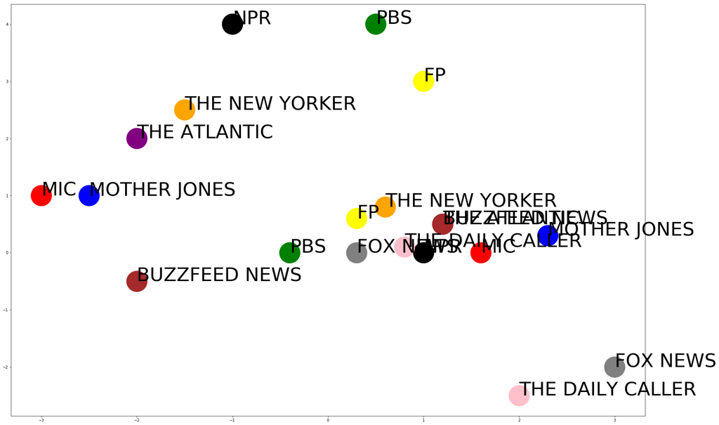

```python
def make_plot(df, selections):
    x = df.iloc[:,0]
    y = df.iloc[:,1]
    fig, ax = plt.subplots(figsize = (30,20))
    ax.scatter(x,y,c = colors, s = 3000)
    for i, txt in enumerate(selections):
        ax.annotate(txt, (x[i],y[i]), size = 50)

make_plot(massive, massive_selections)
```

```python
x = massive.iloc[:,0]
y = massive.iloc[:,1]
```

Defining a function to show us the movement of each dot

```python
plt.close("all")
def make_arrow_plot(selections, x, y):
    fig, ax = plt.subplots(figsize=(30, 20))
    ax.scatter(x,y, c = colors, s = 3000)
    for i, txt in enumerate(selections):
        ax.annotate(txt, (x[i],y[i]), size = 40)
        for i in np.arange(10):
            plt.plot(x[i], y[i])
            plt.arrow(x[i], y[i], (x[i+10]-x[i]),
                      (y[i+10]-y[i]), linewidth = 10,
                      length_includes_head = True,
                      head_width = .1)
```

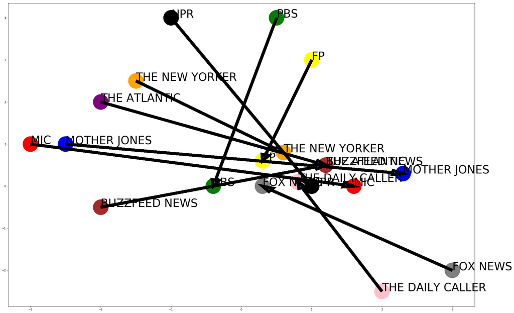

```python
show_trial0 = make_arrow_plot(massive_selections, x,y)
show_trial0
```

```python
plt.close("all")
```

```python
all_words
```

[output not shown]

[output cut: 946 more lines]

```
  'do',
  'battle',
  'with',
  'the',
  'secularhumanist',
  'coastal',
  'élites',
  'who',
  'are',
  'so',
  'obsessed',
  'with',
  'identity',
  'politics',
  ...]]
```

Looking at word counts

```python
words_counts = pd.DataFrame(data = all_word_count, index = np.arange(1))#, columns = np.arange(1784))

words_counts.loc[-1] = np.arange(1786)  # adding a row
words_counts.index = words_counts.index + 1  # shifting index
words_counts = words_counts.sort_index()  # sorting by index
words_counts.loc[0] = words_counts.columns
words_counts#.columns
```

|  | '1', | '10', | '100', | '1052', | '111', | '1198', | '13', | '15', | '1k', | '1y', | ... | 'years', | 'yet', | 'york', | 'yorkbased', | 'young', | 'youre', | 'youth', | 'zapad', | 'élites', | ['sasha', |
| --- | --- | --- | --- | --- | --- | --- | --- | --- | --- | --- | --- | --- | --- | --- | --- | --- | --- | --- | --- | --- | --- |
| 0 | '1', | '10', | '100', | '1052', | '111', | '1198', | '13', | '15', | '1k', | '1y', | ... | 'years', | 'yet', | 'york', | 'yorkbased', | 'young', | 'youre', | 'youth', | 'zapad', | 'élites', | ['sasha', |
| 1 | 3 | 1 | 2 | 1 | 1 | 1 | 1 | 3 | 1 | 1 | ... | 5 | 6 | 1 | 1 | 2 | 1 | 2 | 2 | 1 | 1 |

2 rows × 1786 columns

```python
HELP = {}
for i in np.arange(1784):
    HELP[i]=[i]
    #words_counts.rename(columns = {HELP, i})
HELP
words_counts.rename(columns = HELP)
#HELP
#words_counts
#words_counts = pd.DataFrame(data = words_counts, columns = np.arange(1784))
```

|  | '1', | '10', | '100', | '1052', | '111', | '1198', | '13', | '15', | '1k', | '1y', | ... | 'years', | 'yet', | 'york', | 'yorkbased', | 'young', | 'youre', | 'youth', | 'zapad', | 'élites', | ['sasha', |
| --- | --- | --- | --- | --- | --- | --- | --- | --- | --- | --- | --- | --- | --- | --- | --- | --- | --- | --- | --- | --- | --- |
| 0 | '1', | '10', | '100', | '1052', | '111', | '1198', | '13', | '15', | '1k', | '1y', | ... | 'years', | 'yet', | 'york', | 'yorkbased', | 'young', | 'youre', | 'youth', | 'zapad', | 'élites', | ['sasha', |
| 1 | 3 | 1 | 2 | 1 | 1 | 1 | 1 | 3 | 1 | 1 | ... | 5 | 6 | 1 | 1 | 2 | 1 | 2 | 2 | 1 | 1 |

2 rows × 1786 columns

# What are the most common words?

```python
pd.set_option('display.max_columns', None)
all_words_df = words_counts.sort_values(by = [1], axis = 1, ascending = False)
all_words_df
```

|  | 'transgender', | 'military', | 'trump', | 'people', | 'policy', | 'said', | 'new', | 'ban', | 'defense', | 'one', | 'court', | 'trans', | 'secretary', | 'department', | 'us', | 'trumps', | 'could', | 'president', | 'mario', | 'troops', | 'would', | 'service', | 'south', | 'administration', | 'mattis', | 'says', | 'pentagon', | 'country', | 'shares', | … |
| --- | --- | --- | --- | --- | --- | --- | --- | --- | --- | --- | --- | --- | --- | --- | --- | --- | --- | --- | --- | --- | --- | --- | --- | --- | --- | --- | --- | --- | --- | --- |
| 0 | 'transgender', | 'military', | 'trump', | 'people', | 'policy', | 'said', | 'new', | 'ban', | 'defense', | 'one', | 'court', | 'trans', | 'secretary', | 'department', | 'us', | 'trumps', | 'could', | 'president', | 'mario', | 'troops', | 'would', | 'service', | 'south', | 'administration', | 'mattis', | 'says', | 'pentagon', | 'country', | 'shares', | … |
| 1 | 53 | 36 | 28 | 27 | 27 | 26 | 22 | 20 | 18 | 17 | 15 | 15 | 15 | 14 | 14 | 14 | 14 | 13 | 12 | 12 | 11 | 11 | 11 | 11 | 11 | 11 | 11 | 10 | 10 | … |

Let's use this info to make new keywords.

```python
new_keywords = ["transgender", "people", "court", "trans", "us", "shares", "would", "violence", "justice", "lgbtq",
               "victim", "victims", "'transition'", "hrc", "dysphoria", "misgendered"]
new_keywords_neg = ["military", "policy", "new", "ban", "diagnosis", "transgendered", "identified", "former",
                    "lie", "lies", "crazy", "detransitioners", "biological", "reality", "transitioners",
                    "transgenderism", "transgenders", "numbskulls"]
new_keywords_trump = ["trump", "TRUMP", "Trump","trumps"]
new_keywords_adm = ["president", "administration", "country", "pentagon", "national", "government", "officials",
                   "american"]
conservative_train_list = ["FP", "PBS", "FOX NEWS", "THE DAILY CALLER"]
liberal_train_list = ["MIC", "THE NEW YORKER", "MOTHER JONES", "THE ATLANTIC", "NPR", "BUZZFEED NEWS"]
conservative_train = tokenized_train.loc[conservative_train_list]
liberal_train = tokenized_train.loc[liberal_train_list]
```

```python
def keyword_counts_bipartisan(df, pos_list, neg_list):
    leng = len(df.iloc[0:,:0])
    le = len(df.iloc[0])
    lists = []
    for i in np.arange(leng):
        keys = ((le)-(df.iloc[i].isin(pos_list)).value_counts()[0])-((le)-(df.iloc[i].isin(neg_list)).value_counts()[0])
        lists = np.append(lists, keys)
    key = pd.DataFrame(index = [df.index], data = lists)
    return key
cons_keys = keyword_counts_bipartisan(conservative_train, new_keywords,
                                      new_keywords_neg).rename(columns = {0:"x"})
lib_keys = (keyword_counts_bipartisan(liberal_train, new_keywords,
                                      new_keywords_neg)).rename(columns = {0:"x"})/10
cons_trump = keyword_counts_bipartisan(conservative_train, new_keywords_trump,
                                       new_keywords_adm).rename(columns = {0:"y"})/10
lib_trump = keyword_counts_bipartisan(liberal_train, new_keywords_trump,
                                      new_keywords_adm).rename(columns = {0:"y"})/10
```

```python
cons_to_graph = pd.concat([cons_keys, cons_trump], axis=1, join_axes=[cons_keys.index])
libs_to_graph = pd.concat([lib_keys, lib_trump], axis = 1, join_axes=[lib_keys.index])
keys_to_graph = pd.concat([cons_keys, lib_keys])
trump_to_graph = pd.concat([cons_trump, lib_trump])
to_graph = pd.concat([keys_to_graph, trump_to_graph])

#massive2 = pd.concat([to_graph, media_bias_train])
#massive2.reindex(["MIC", "THE NEW YORKER", "FP","PBS", "MOTHER JONES", "THE ATLANTIC", "FOX NEWS", "NPR",
      #            "BUZZFEED NEWS", "THE DAILY CALLER"])
KEY = keys_to_graph.join(trump_to_graph).reindex(index = [selections_train])
massive2 = pd.concat([KEY, media_bias_train])
massive2
```

|  | x | y |
| --- | --- | --- |
| MIC | 2.0 | -0.2 |
| THE NEW YORKER | 0.1 | -0.1 |
| FP | 9.0 | -1.9 |
| PBS | 0.0 | -0.1 |
| MOTHER JONES | 3.2 | -0.2 |
| THE ATLANTIC | 0.1 | -0.2 |
| FOX NEWS | 4.0 | -0.2 |
| NPR | 1.4 | 0.0 |
| BUZZFEED NEWS | -0.4 | -1.1 |
| THE DAILY CALLER | -1.0 | -0.1 |
| MIC | -3.0 | 1.0 |
| THE NEW YORKER | -1.5 | 2.5 |
| FP | 1.0 | 3.0 |
| PBS | 0.5 | 4.0 |
| MOTHER JONES | -2.5 | 1.0 |
| THE ATLANTIC | -2.0 | 2.0 |
| FOX NEWS | 3.0 | -2.0 |
| NPR | -1.0 | 4.0 |
| BUZZFEED NEWS | -2.0 | -0.5 |
| THE DAILY CALLER | 2.0 | -2.5 |

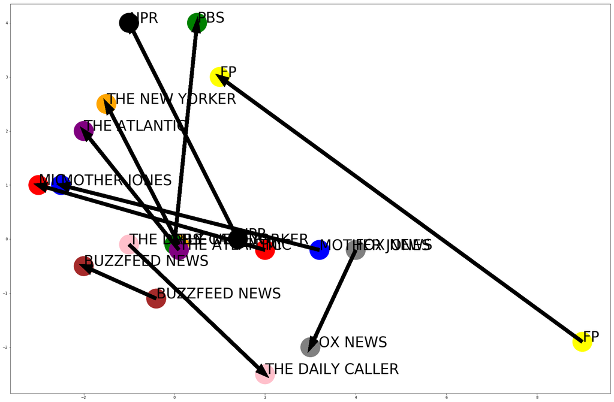

```python
show_trial1 = make_arrow_plot(massive2.index, massive2.iloc[:,0],massive2.iloc[:,1])
show_trial1
```

```python
plt.close("all")
```